# Mushroom Classification Machine Learning - Neural Models

# K-Means Clustering

K-Means is a clustering algorithm that groups data points into K clusters based on their similarity. I want to extract features from the images and then apply K-Means clustering to see how images are grouped together.

```python
from tensorflow.keras.applications import VGG16
from tensorflow.keras.preprocessing import image
from tensorflow.keras.applications.vgg16 import preprocess_input
from sklearn.cluster import KMeans
import random
from tensorflow.keras.models import Model
```

```python
# Feature Extraction
base_model = VGG16(weights='imagenet', include_top=False, input_shape=(150, 150, 3))  # Don't include the top layer
model = Model(inputs=base_model.input, outputs=base_model.output)

# Using VGG16, pre-trained Convolutional Neural Network (CNN) model
```

```python
#Image Resizing and Feature Extraction
def extract_features_from_folder(folder_path, target_size=(150, 150)):
    feature_list = []
    image_paths = []
    genus_labels = []

    for genus_name in os.listdir(folder_path):
        genus_folder = os.path.join(folder_path, genus_name)
        if os.path.isdir(genus_folder):
            for image_file in os.listdir(genus_folder):
                img_path = os.path.join(genus_folder, image_file)

                # Load image
                img = image.load_img(img_path, target_size=target_size)
                img_array = image.img_to_array(img)
                img_array = np.expand_dims(img_array, axis=0)
                img_array = preprocess_input(img_array)

                # Extract features
                features = model.predict(img_array)
                features = features.flatten()  # Flatten to 1D array

                feature_list.append(features)
                image_paths.append(img_path)
                genus_labels.append(genus_name)

    return np.array(feature_list), image_paths, genus_labels

# Extract features from the dataset
features, image_paths, genus_labels = extract_features_from_folder(unified_folder)
```

```python
# K-Means Clustering Application
n_clusters = 5  # 5 genuses
kmeans = KMeans(n_clusters=n_clusters, random_state=42)
kmeans.fit(features)
```

```
KMeans(n_clusters=5, random_state=42)
```

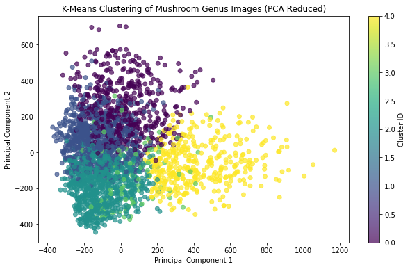

```python
# Using PCA to reduce dimension to 2D and plotting the clusters
from sklearn.decomposition import PCA

pca = PCA(n_components=2)
reduced_features = pca.fit_transform(features)

# Plot the clusters
plt.figure(figsize=(10, 6))
plt.scatter(reduced_features[:, 0], reduced_features[:, 1], c=kmeans.labels_, cmap='viridis', alpha=0.7)
plt.title('K-Means Clustering of Mushroom Genus Images (PCA Reduced)')
plt.xlabel('Principal Component 1')
plt.ylabel('Principal Component 2')
plt.colorbar(label='Cluster ID')
plt.show()
```

[figure not shown]

```python
# Images from each cluster
cluster_images = {i: [] for i in range(n_clusters)}

for i, label in enumerate(kmeans.labels_):
    cluster_images[label].append(image_paths[i])

plt.figure(figsize=(12, 12))
for i in range(n_clusters):
    plt.subplot(n_clusters, 1, i + 1)
    random_image_path = random.choice(cluster_images[i])
    img = plt.imread(random_image_path)
    plt.imshow(img)
    plt.title(f"Cluster {i}")
    plt.axis('off')

plt.tight_layout()
```

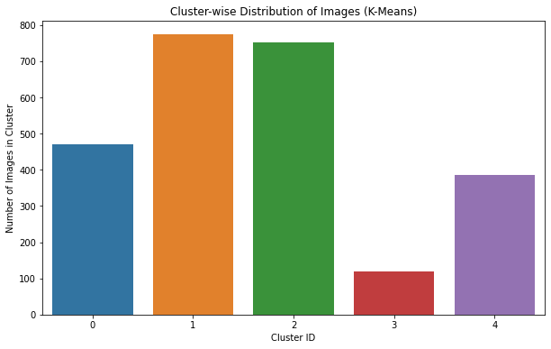

```python
cluster_counts = [np.sum(kmeans.labels_ == i) for i in range(n_clusters)]

plt.figure(figsize=(10, 6))
sns.barplot(x=list(range(n_clusters)), y=cluster_counts)
plt.title('Cluster-wise Distribution of Images (K-Means)')
plt.xlabel('Cluster ID')
plt.ylabel('Number of Images in Cluster')
plt.show()
```

```python
# Analyzing how genus labels are distributed across clusters
cluster_genus_distribution = {i: [] for i in range(n_clusters)}
for i, label in enumerate(kmeans.labels_):
    cluster_genus_distribution[label].append(genus_labels[i])

# Distribution of genera in each cluster
cluster_genus_counts = {i: {} for i in range(n_clusters)}
for cluster_id, genera in cluster_genus_distribution.items():
    for genus in genera:
        if genus in cluster_genus_counts[cluster_id]:
            cluster_genus_counts[cluster_id][genus] += 1
        else:
            cluster_genus_counts[cluster_id][genus] = 1

# Counts of genera per cluster
for cluster_id, counts in cluster_genus_counts.items():
    print(f"Cluster {cluster_id}:")
    for genus, count in counts.items():
        print(f"  {genus}: {count} images")
    print()
```

```
Cluster 0:
  Lactarius: 105 images
  Russula: 99 images
  Boletus: 23 images
  Amanita: 91 images
  Cortinarius: 152 images

Cluster 1:
  Lactarius: 212 images
  Russula: 184 images
  Boletus: 140 images
  Amanita: 79 images
  Cortinarius: 159 images

Cluster 2:
  Lactarius: 117 images
  Russula: 163 images
  Boletus: 151 images
  Amanita: 180 images
  Cortinarius: 141 images

Cluster 3:
  Lactarius: 48 images
  Russula: 27 images
  Amanita: 11 images
  Cortinarius: 33 images

Cluster 4:
  Lactarius: 18 images
  Russula: 27 images
  Boletus: 186 images
  Amanita: 139 images
  Cortinarius: 15 images
```

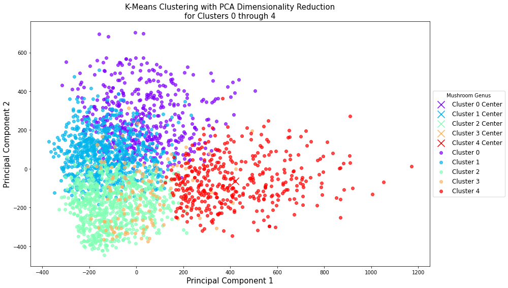

```python
# 2D PCA visualization with cluster labels and genus information
plt.figure(figsize=(14, 8))
colors = plt.cm.rainbow(np.linspace(0, 1, n_clusters))  # Color map for clusters

for i in range(n_clusters):
    # Calculate the mean (centroid) of the cluster in the reduced feature space
    class_center = np.mean(reduced_features[kmeans.labels_ == i], axis=0)

    # Plot the centroid as a large 'x'
    plt.scatter(class_center[0], class_center[1], color=colors[i], s=200, marker='x', label=f'Cluster {i} Center')

# Plot the clusters with the PCA-reduced features
for i in range(n_clusters):
    plt.scatter(reduced_features[kmeans.labels_ == i, 0],
                reduced_features[kmeans.labels_ == i, 1],
                label=f'Cluster {i}',
                color=colors[i], alpha=0.7)

plt.title(f'K-Means Clustering with PCA Dimensionality Reduction\nfor Clusters 0 through {n_clusters - 1}', fontsize=15)
plt.xlabel('Principal Component 1', fontsize=15)
plt.ylabel('Principal Component 2', fontsize=15)
plt.legend(loc='center left', bbox_to_anchor=(1, 0.5), title="Mushroom Genus", fontsize=12)
plt.tight_layout()
plt.show()
```

Supervised (or Self-Supervised) Machine Learning Models

# CNN Model

I chose a Convolutional Neural Network model to process and analyze the images.

```python
# Splitting Data Into Training, Validation, and Testing Sets

from sklearn.model_selection import train_test_split
from tensorflow.keras.preprocessing import image
from tensorflow.keras.utils import to_categorical

unified_folder = 'unified_folder'
image_paths = []
labels = []
genus_names = os.listdir(unified_folder)

# Assign numerical labels to each genus
label_map = {genus: idx for idx, genus in enumerate(genus_names)}

for genus_name in os.listdir(unified_folder):
    genus_folder = os.path.join(unified_folder, genus_name)
    if os.path.isdir(genus_folder):
        for image_file in os.listdir(genus_folder):
            image_paths.append(os.path.join(genus_folder, image_file))
            labels.append(label_map[genus_name])

labels = to_categorical(labels)

# Split data into training (80%), validation (10%), and testing (10%) sets
train_paths, test_paths, train_labels, test_labels = train_test_split(image_paths, labels, test_size=0.2, random_state=42)

# Further split the training set into training (80%) and validation (20%) sets
train_paths, val_paths, train_labels, val_labels = train_test_split(train_paths, train_labels, test_size=0.2, random_state=42)

# Print the number of images in each set for confirmation
print(f'Training images: {len(train_paths)}')
print(f'Validation images: {len(val_paths)}')
print(f'Test images: {len(test_paths)}')
```

```
Training images: 1600
Validation images: 400
Test images: 500
```

```python
# Resizing and Normalization

# Function to load and preprocess images
def load_and_preprocess_image(img_path, target_size=(150, 150)):
    img = image.load_img(img_path, target_size=target_size)
    img_array = image.img_to_array(img)
    img_array = np.expand_dims(img_array, axis=0)
    return img_array / 255.0

# Load and preprocess the images for training, validation, and testing
train_data = np.vstack([load_and_preprocess_image(img_path) for img_path in train_paths])
val_data = np.vstack([load_and_preprocess_image(img_path) for img_path in val_paths])
test_data = np.vstack([load_and_preprocess_image(img_path) for img_path in test_paths])
```

```python
# CNN Model

from tensorflow.keras.models import Sequential
from tensorflow.keras.layers import Conv2D, MaxPooling2D, Flatten, Dense, Dropout
from tensorflow.keras.optimizers import Adam

model = Sequential([
    Conv2D(32, (3, 3), activation='relu', input_shape=(150, 150, 3)),
    MaxPooling2D(pool_size=(2, 2)),

    Conv2D(64, (3, 3), activation='relu'),
    MaxPooling2D(pool_size=(2, 2)),

    Conv2D(128, (3, 3), activation='relu'),
    MaxPooling2D(pool_size=(2, 2)),

    Flatten(),
    Dense(128, activation='relu'),
    Dropout(0.5),
    Dense(len(genus_names), activation='softmax')  # Number of classes = to number of genuses
])

# Compile
model.compile(optimizer=Adam(), loss='categorical_crossentropy', metrics=['accuracy'])

# Summary
model.summary()
```

```
Model: "sequential_3"
_________________________________________________________________
 Layer (type)                Output Shape              Param #
=================================================================
 conv2d_3 (Conv2D)           (None, 148, 148, 32)      896

 max_pooling2d_3 (MaxPooling  (None, 74, 74, 32)       0
 2D)

 conv2d_4 (Conv2D)           (None, 72, 72, 64)        18496

 max_pooling2d_4 (MaxPooling  (None, 36, 36, 64)       0
 2D)

 conv2d_5 (Conv2D)           (None, 34, 34, 128)       73856

 max_pooling2d_5 (MaxPooling  (None, 17, 17, 128)      0
 2D)

 flatten_3 (Flatten)         (None, 36992)             0

 dense_10 (Dense)            (None, 128)               4735104

 dropout_5 (Dropout)         (None, 128)               0

 dense_11 (Dense)            (None, 5)                 645

=================================================================
Total params: 4,828,997
Trainable params: 4,828,997
Non-trainable params: 0
_________________________________________________________________
```

```python
from tensorflow.keras.preprocessing.image import ImageDataGenerator

# Data augmentation for better generalization
datagen = ImageDataGenerator(
    rotation_range=20,
    width_shift_range=0.2,
    height_shift_range=0.2,
    shear_range=0.2,
    zoom_range=0.2,
    horizontal_flip=True,
    fill_mode='nearest'
)

# Fit the model with augmented data
history = model.fit(
    datagen.flow(train_data, train_labels, batch_size=32),
    validation_data=(val_data, val_labels),
    epochs=10,
    steps_per_epoch=len(train_data) // 32,
    validation_steps=len(val_data) // 32
)
```

```python
# Evaluate the model on the test set
test_loss, test_accuracy = model.evaluate(test_data, test_labels)
print(f'Test Loss: {test_loss}')
print(f'Test Accuracy: {test_accuracy}')
```

```
Test Loss: 1.5036884546279907
Test Accuracy: 0.3479999899864197
```

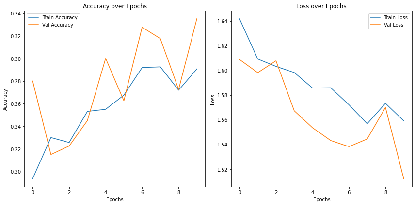

```python
# Plot training & validation accuracy
plt.figure(figsize=(12, 6))
plt.subplot(1, 2, 1)
plt.plot(history.history['accuracy'], label='Train Accuracy')
plt.plot(history.history['val_accuracy'], label='Val Accuracy')
plt.title('Accuracy over Epochs')
plt.xlabel('Epochs')
plt.ylabel('Accuracy')
plt.legend()

# Plot training & validation loss
plt.subplot(1, 2, 2)
plt.plot(history.history['loss'], label='Train Loss')
plt.plot(history.history['val_loss'], label='Val Loss')
plt.title('Loss over Epochs')
plt.xlabel('Epochs')
plt.ylabel('Loss')
plt.legend()

plt.tight_layout()
plt.show()
```

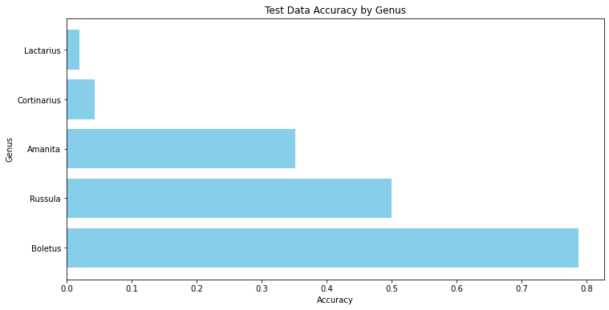

```python
# Model predictions on the test set
test_preds = model.predict(test_data)
test_preds_class = np.argmax(test_preds, axis=1)
test_labels_class = np.argmax(test_labels, axis=1)

# Accuracy for each genus
genus_accuracy = {genus: 0 for genus in genus_names}

correct_per_genus = {genus: 0 for genus in genus_names}
total_per_genus = {genus: 0 for genus in genus_names}
for i, pred in enumerate(test_preds_class):
    true_genus = genus_names[test_labels_class[i]]
    predicted_genus = genus_names[pred]

    total_per_genus[true_genus] += 1
    if true_genus == predicted_genus:
        correct_per_genus[true_genus] += 1

# Accuracy per genus
for genus in genus_names:
    genus_accuracy[genus] = correct_per_genus[genus] / total_per_genus[genus]


sorted_genus = sorted(genus_accuracy.items(), key=lambda item: item[1], reverse=True)

# Sorted genus names and accuracy values for plotting
genus_names_sorted = [x[0] for x in sorted_genus]
accuracy_sorted = [x[1] for x in sorted_genus]

# Test Data accuracy by genus
plt.figure(figsize=(12, 6))
plt.barh(genus_names_sorted, accuracy_sorted, color='skyblue')
plt.title('Test Data Accuracy by Genus')
plt.xlabel('Accuracy')
plt.ylabel('Genus')
plt.show()
```

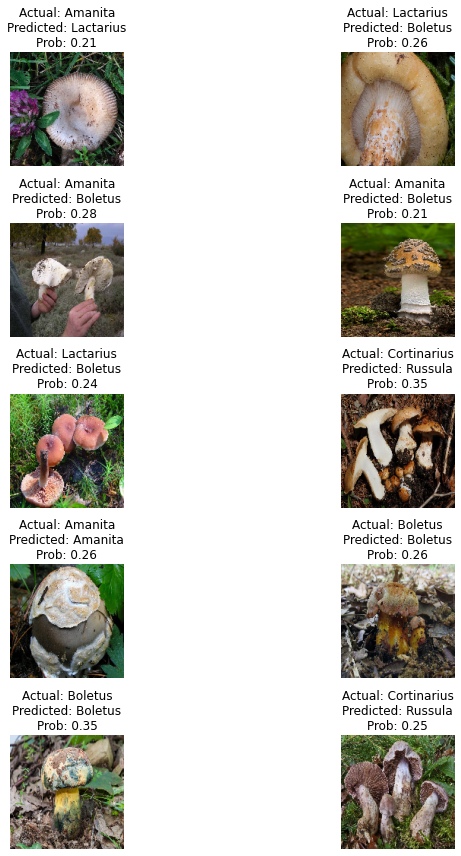

```python
# Model predictions on the test set
test_preds = model.predict(test_data)
test_preds_class = np.argmax(test_preds, axis=1)
test_labels_class = np.argmax(test_labels, axis=1)

# Subset of random indices for visualization
num_samples = 10
random_indices = random.sample(range(len(test_preds_class)), num_samples)

plt.figure(figsize=(12, 12))
for i, idx in enumerate(random_indices):
    img_path = test_paths[idx]
    true_genus = genus_names[test_labels_class[idx]]
    predicted_genus = genus_names[test_preds_class[idx]]
    predicted_prob = test_preds[idx][test_preds_class[idx]]
    img = image.load_img(img_path, target_size=(150, 150))
    plt.subplot(5, 2, i + 1)
    plt.imshow(img)
    plt.axis('off')
    plt.title(f"Actual: {true_genus}\nPredicted: {predicted_genus}\nProb: {predicted_prob:.2f}")

plt.tight_layout()
plt.show()
```

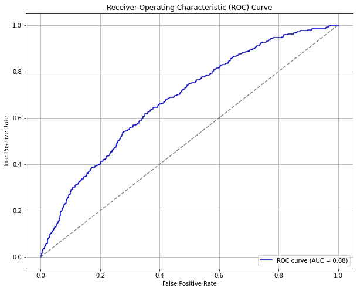

```python
from sklearn.metrics import roc_curve, auc
from sklearn.preprocessing import label_binarize

y_test_bin = label_binarize(test_labels_class, classes=np.arange(len(genus_names)))
y_pred_prob = model.predict(test_data)
fpr, tpr, _ = roc_curve(y_test_bin.ravel(), y_pred_prob.ravel())
roc_auc = auc(fpr, tpr)

plt.figure(figsize=(10, 8))
plt.plot(fpr, tpr, color='b', label=f'ROC curve (AUC = {roc_auc:.2f})')
plt.plot([0, 1], [0, 1], color='gray', linestyle='--')
plt.title('Receiver Operating Characteristic (ROC) Curve')
plt.xlabel('False Positive Rate')
plt.ylabel('True Positive Rate')
plt.legend(loc='lower right')
plt.grid(True)
plt.show()
```

# DNN Model

Deep neural network

```python
import tensorflow as tf
from tensorflow.keras.callbacks import EarlyStopping

model = Sequential()

model.add(Flatten(input_shape=(150, 150, 3)))
model.add(Dense(1024, activation='relu'))
model.add(Dropout(0.5))
model.add(Dense(512, activation='relu'))
model.add(Dropout(0.5))
model.add(Dense(256, activation='relu'))
model.add(Dense(train_labels.shape[1], activation='softmax'))
model.compile(optimizer=Adam(), loss='categorical_crossentropy', metrics=['accuracy'])


model.summary()
early_stopping = EarlyStopping(monitor='val_loss', patience=5, restore_best_weights=True)

# Train the model
history = model.fit(
    train_data,
    train_labels,
    epochs=50,
    batch_size=32,
    validation_data=(val_data, val_labels),
    callbacks=[early_stopping]
)
```

```
Model: "sequential_2"
_________________________________________________________________
 Layer (type)                Output Shape              Param #
=================================================================
 flatten_2 (Flatten)         (None, 67500)             0

 dense_6 (Dense)             (None, 1024)              69121024

 dropout_3 (Dropout)         (None, 1024)              0

 dense_7 (Dense)             (None, 512)               524800

 dropout_4 (Dropout)         (None, 512)               0

 dense_8 (Dense)             (None, 256)               131328

 dense_9 (Dense)             (None, 5)                 1285

=================================================================
Total params: 69,778,437
Trainable params: 69,778,437
Non-trainable params: 0
_________________________________________________________________
```

```python
test_loss, test_acc = model.evaluate(test_data, test_labels)
print(f"Test accuracy: {test_acc}")
```

```
Test accuracy: 0.24400000274181366
```

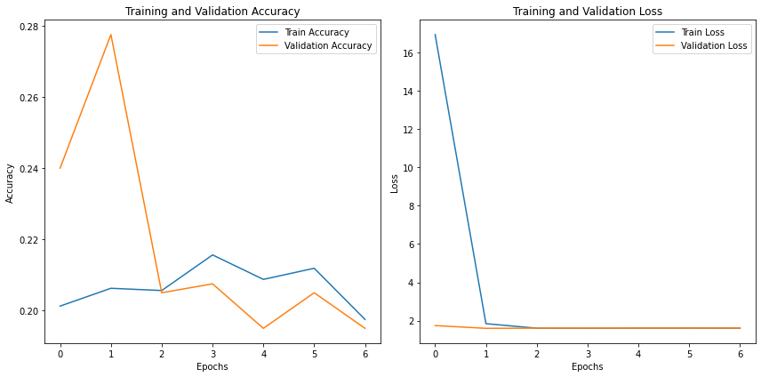

```python
# Training & Validation accuracy
plt.figure(figsize=(12, 6))
plt.subplot(1, 2, 1)
plt.plot(history.history['accuracy'], label='Train Accuracy')
plt.plot(history.history['val_accuracy'], label='Validation Accuracy')
plt.title('Training and Validation Accuracy')
plt.xlabel('Epochs')
plt.ylabel('Accuracy')
plt.legend()

# Training & Validation loss
plt.subplot(1, 2, 2)
plt.plot(history.history['loss'], label='Train Loss')
plt.plot(history.history['val_loss'], label='Validation Loss')
plt.title('Training and Validation Loss')
plt.xlabel('Epochs')
plt.ylabel('Loss')
plt.legend()

plt.tight_layout()
plt.show()
```

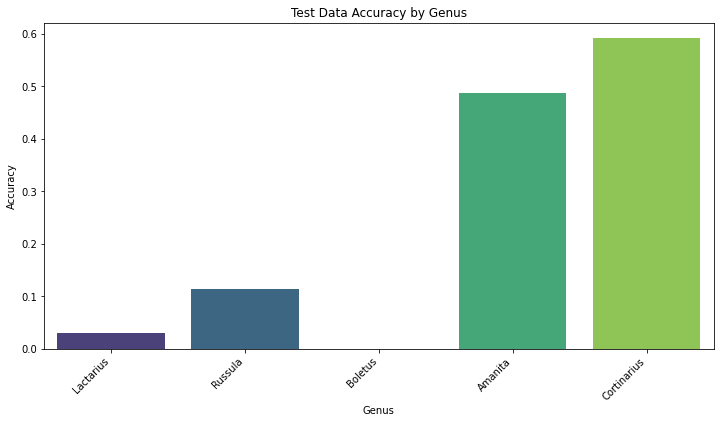

```python
from sklearn.metrics import accuracy_score
import seaborn as sns

test_predictions = model.predict(test_data)
predicted_labels = np.argmax(test_predictions, axis=1)
true_labels = np.argmax(test_labels, axis=1)

genus_accuracy = {}

for genus_index in np.unique(true_labels):
    genus_indices = np.where(true_labels == genus_index)[0]
    genus_true_labels = true_labels[genus_indices]
    genus_predicted_labels = predicted_labels[genus_indices]
    accuracy = accuracy_score(genus_true_labels, genus_predicted_labels)
    genus_accuracy[genus_index] = accuracy

sorted_genus_accuracy = {genus_names[i]: genus_accuracy[i] for i in genus_accuracy}

plt.figure(figsize=(12, 6))
sns.barplot(x=list(sorted_genus_accuracy.keys()), y=list(sorted_genus_accuracy.values()), palette='viridis')
plt.title('Test Data Accuracy by Genus')
plt.xlabel('Genus')
plt.ylabel('Accuracy')
plt.xticks(rotation=45, ha='right')
plt.show()
```

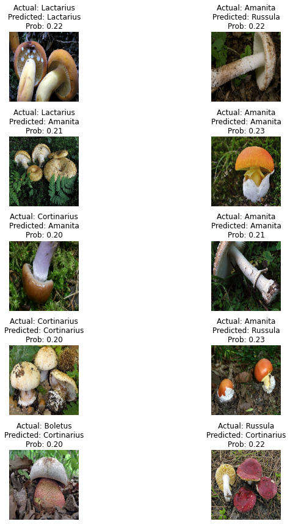

```python
test_preds = model.predict(test_data)
test_preds_class = np.argmax(test_preds, axis=1)
test_labels_class = np.argmax(test_labels, axis=1)

num_samples = 10
random_indices = random.sample(range(len(test_preds_class)), num_samples)

plt.figure(figsize=(12, 12))
for i, idx in enumerate(random_indices):
    img_path = test_paths[idx]
    true_genus = genus_names[test_labels_class[idx]]
    predicted_genus = genus_names[test_preds_class[idx]]
    predicted_prob = test_preds[idx][test_preds_class[idx]]
    img = image.load_img(img_path, target_size=(150, 150))

    plt.subplot(5, 2, i + 1)
    plt.imshow(img)
    plt.axis('off')
    plt.title(f"Actual: {true_genus}\nPredicted: {predicted_genus}\nProb: {predicted_prob:.2f}")

plt.tight_layout()
plt.show()
```

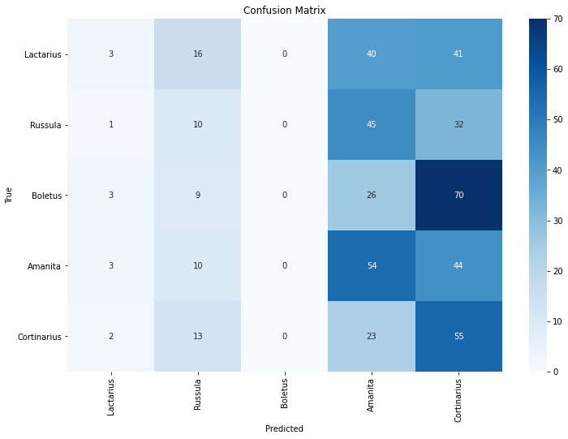

```python
from sklearn.metrics import confusion_matrix

# Confusion matrix
cm = confusion_matrix(test_labels_class, test_preds_class)
plt.figure(figsize=(12, 8))
sns.heatmap(cm, annot=True, fmt='d', cmap='Blues', xticklabels=genus_names, yticklabels=genus_names)
plt.title('Confusion Matrix')
plt.xlabel('Predicted')
plt.ylabel('True')
plt.xticks(rotation=90)
plt.yticks(rotation=0)
plt.show()
```

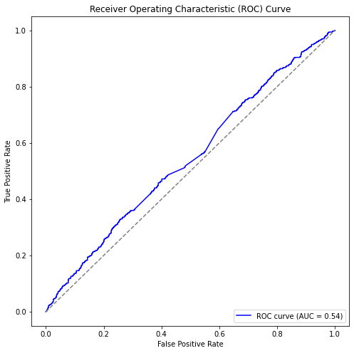

```python
from sklearn.metrics import roc_curve, auc
from sklearn.preprocessing import label_binarize

# Binarize the labels for multi-class ROC
y_test_bin = label_binarize(test_labels_class, classes=np.arange(len(genus_names)))
y_pred_bin = model.predict(test_data)

fpr, tpr, _ = roc_curve(y_test_bin.ravel(), y_pred_bin.ravel())
roc_auc = auc(fpr, tpr)

# Plot ROC curve
plt.figure(figsize=(8, 8))
plt.plot(fpr, tpr, color='b', label=f'ROC curve (AUC = {roc_auc:.2f})')
plt.plot([0, 1], [0, 1], color='gray', linestyle='--')
plt.title('Receiver Operating Characteristic (ROC) Curve')
plt.xlabel('False Positive Rate')
plt.ylabel('True Positive Rate')
plt.legend(loc='lower right')
plt.show()
```

ROC curve visualizes the performance of a classifier across different classification thresholds.

AUC is the overall perfomance of the model. The higher, the more accurate.

```python
from sklearn.metrics import classification_report

# Get precision, recall, and F1 score
report = classification_report(test_labels_class, test_preds_class, target_names=genus_names)
print(report)
```

```
              precision    recall  f1-score   support

   Lactarius       0.25      0.03      0.05       100
     Russula       0.17      0.11      0.14        88
     Boletus       0.00      0.00      0.00       108
     Amanita       0.29      0.49      0.36       111
 Cortinarius       0.23      0.59      0.33        93

    accuracy                           0.24       500
   macro avg       0.19      0.24      0.18       500
weighted avg       0.19      0.24      0.18       500
```

# Conclusions

When comparing the CNN and DNN model, the CNN model perfomed better. It had a higher test accuracy, and AUC. It also had a lower test loss.

CNN

- Test Loss: 1.5037
- Test Accuracy: 0.3480
- AUC = 0.68

DNN

- Test Loss: 1.6045
- Test accuracy: 0.2440
- AUC = 0.54

This makes sense since CNNs are more efficient for image-related modeling.

These images were dificult to differentiate. More tuning as well as different models could produce a higher accuracy. I really wish the images were clearer. Many contained background foliage. Having really exact images for training and then having in-the-field images for testing would be very interesting. Having 360 images would also be something very cool to look into.